# Part II - Flights dataset

## Investigation Overview

> In this presentation i will try to answer effectively to the three questions (Are there certain destination or arrival cities that experience more delays or cancellations? What are the main factors behind the cancellation of flights? What are the preferred times for flights to occur?) Firstly we will have a global view of all delayed flights and how they are distributed in dataset. After, we will see have more visibility about cancelled flights in dataset. Then we will apreciate the real impact of great factors delays followed by cancellation factors impact according to city and time. Finally we will have a final overview of flights delay per month on 10 most frequent cities/countries.

## Dataset Overview

```python
# import all packages and set plots to be embedded inline
import numpy as np
import pandas as pd
import matplotlib.pyplot as plt
import seaborn as sb

%matplotlib inline

# suppress warnings from final output
import warnings
warnings.simplefilter("ignore")
```

```python
# load in the dataset into a pandas dataframe
df = pd.read_csv('./flights_dataset.csv')
```

```python
cols_selected = ['Year', 'Month', 'DayofMonth', 'DayOfWeek', 'ArrDelay',
       'DepDelay','Origin','Dest','Cancelled', 'CancellationCode', 'Diverted', 'CarrierDelay',
       'WeatherDelay', 'NASDelay', 'SecurityDelay', 'LateAircraftDelay']
df= df[cols_selected]
df['Cancelled'].replace({0: 'Not Cancelled', 1: 'Cancelled'},inplace =True)
df['CancellationCode'].replace({'A':'Carrier','B':'Weather', 'C':'NAS', 'D':'Security'}, inplace =True)
df['Month'].replace({1:'JAN',2:'FEB',3:'MAR',4:'APR',5:'MAY',6:'JUN',7:'JUL',8:'AUG',9:'SEP',10:'OCT',11:'NOV',12:'DEC'}, inplace=True)
df['DayOfWeek'].replace({1:'Monday',2:'Tuesday',3:'Wednesday',4:'Thursday',5:'Friday',6:'Saturday',7:'Sunday'},inplace = True)
df.DayOfWeek.value_counts()

# convert Month, Day of week into ordered categorical types
ordinal_var_dict = {'Month': ['JAN','FEB','MAR','APR','MAY','JUN','JUL','AUG','SEP','OCT','NOV','DEC'],
                    'DayOfWeek': ['Monday','Tuesday','Wednesday','Thursday','Friday','Saturday','Sunday'],
                    'CancellationCode': ['Carrier','Weather','NAS','Security']}

for var in ordinal_var_dict:
    ordered_var = pd.api.types.CategoricalDtype(ordered = True,
                                                categories = ordinal_var_dict[var])
    df[var] = df[var].astype(ordered_var)

df.drop_duplicates(inplace=True)
df_1 = df.query('DepDelay >= 0 | DepDelay != DepDelay')
sorted_dest = df_1['Dest'].value_counts()[:10]
df_dest_sorted = df_1[df['Dest'].isin(sorted_dest.index)]
sorted_org = df_1['Origin'].value_counts()[:10]
df_org_sorted = df_1[df_1['Origin'].isin(sorted_org.index)]
df_flights = pd.concat([df_org_sorted,df_dest_sorted],ignore_index=True)
df_flights.drop_duplicates(inplace = True)

# compute the logarithm of price to make multivariate plotting easier
def log_trans(x, inverse = False):
    """ quick function for computing log and power operations """
    if not inverse:
        return np.log10(x)
    else:
        return np.power(10, x)

df_dest_sorted['Log_ArrDelay'] = df_dest_sorted[df_dest_sorted['ArrDelay']!= 0]['ArrDelay'].apply(log_trans)
df_org_sorted['Log_DepDelay'] = df_org_sorted[df_org_sorted['DepDelay']!= 0]['DepDelay'].apply(log_trans)
delay_params =['DepDelay','ArrDelay']
factor_delays =['LateAircraftDelay','NASDelay']
xlabels =['Departure Delay (mn)','Arrival Delay (mn)']
delay_params_log =['Log_DepDelay','Log_ArrDelay']
ylabels = ['Late Aircraft Delay (mn)','NAS Delay (mn)']
df_list =[df_org_sorted,df_dest_sorted]
```

> Note that the above cells have been set as "Skip"-type slides. That means that when the notebook is rendered as http slides, those cells won't show up.

## Distribution of Arrival Delays and Departure Delays of flights

There are more than 24 Millions flights in the dataset with at least 20 features. The distribution is unimodal about the arrival delay time and slightly skewed at right. But that's normal because most of flight haven't delay at arrival.We can notice that the negative Arrival delay means that the airplane arrived early. Same remark on departure delays.

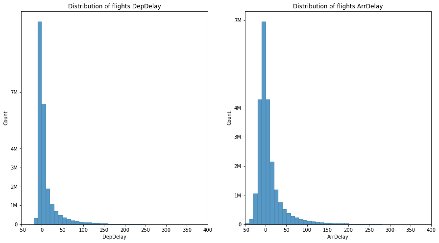

```python
fig, ax =plt.subplots(ncols =2,figsize =[15,8])
for i in range(len(delay_params)):
    binsize = 10
    bins = np.arange(df[delay_params[i]].min(), df[delay_params[i]].max()+binsize, binsize)
    sb.histplot(data = df, x = delay_params[i],bins = bins,ax = ax[i])
    ax[i].set_yticks([0,1e6,2e6,3e6,4e6,7e6])
    ax[i].set_yticklabels([0,'1M','2M','3M','4M','7M'])
    ax[i].set_xlim(-50,400)
    ax[i].set_xlabel(delay_params[i])
    ax[i].set_title('Distribution of flights '+delay_params[i])
```

## Number of flights cancelled on 10 most common destinations

Before going in detail into dataset to filter out main factors responsible of flights cancellation, let's have a global view of dataset content. That could be very difficult for passengers to accept the departures in advance. So i removed the negative departures delays from dataset. The higher number of cancelled flights is on **ORD** followed by **ATL** and **DFW**.

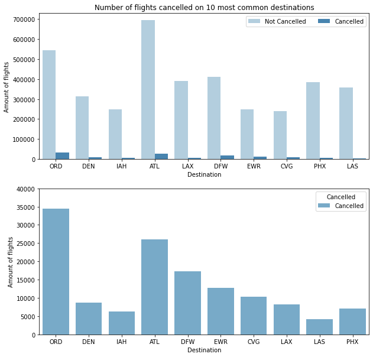

```python
fig, ax = plt.subplots(nrows=2,figsize = [10, 10])
# subplot 1: Destination vs Cancelled state
sb.countplot(data = df_dest_sorted, x = 'Dest', hue = 'Cancelled', palette = "Blues",ax =ax[0])
ax[0].set_ylabel('Amount of flights')
ax[0].set_xlabel('Destination')
ax[0].legend(ncol = 2) # re-arrange legend to reduce overlapping
ax[0].set_title('Number of flights cancelled on 10 most common destinations')

# subplot 2: Destination vs Cancelled state (zoomed)
sb.countplot(data = df_dest_sorted[df_dest_sorted['Cancelled']=='Cancelled'], x = 'Dest', hue = 'Cancelled', palette = "Blues",ax =ax[1])
plt.ylabel('Amount of flights')
ax[1].set_ylim(0,40000)
ax[1].set_xlabel('Destination')
```

## Factors linked to flights late at departure and arrival

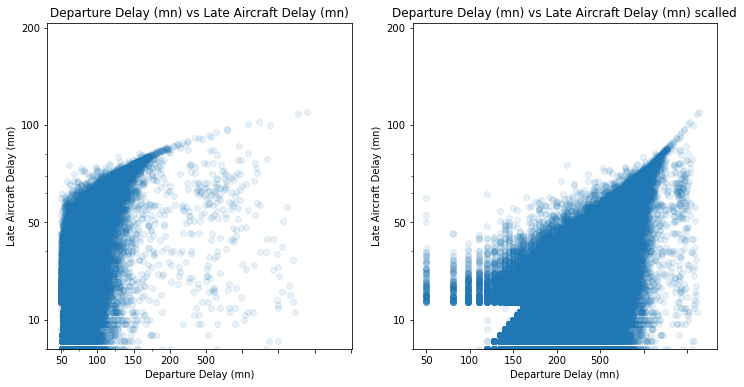

```python
color =sb.color_palette()[0]

fig, ax = plt.subplots(ncols=2, figsize=[12,6])
sb.regplot(data = df_list[0], x = delay_params[0], y = factor_delays[0],fit_reg=False, scatter_kws={'alpha':1/10},ax = ax[0], color =color)
ax[0].set_xlabel(xlabels[0])
ax[0].set_yscale('log')
ax[0].set_xticks([10, 100, 200, 300, 500], [10, 100, 200, 300, 500])
ax[0].set_yticks([5,10,10,50, 100, 200, 300, 500],[5,10,10,50, 100, 200, 300, 500])
ax[0].set_yticklabels([5,10,10,50, 100, 200, 300, 500])
ax[0].set_ylabel(ylabels[0])
ax[0].set_xticklabels([10, 50, 100, 150, 200, 500])
ax[0].set_title(xlabels[0]+' vs '+ylabels[0])

sb.regplot(data = df_list[0], x = delay_params_log[0], y = factor_delays[0],fit_reg=False ,scatter_kws={'alpha':1/10},ax = ax[1], color =color)
ax[1].set_xlabel(xlabels[0])
ax[1].set_yscale('log')
ax[1].set_yticks([5,10,10,50, 100, 200, 300, 500],[5,10,10,50, 100, 200, 300, 500])
ax[1].set_yticklabels([5,10,10,50, 100, 200, 300, 500])
ax[1].set_ylabel(ylabels[0])
ax[1].set_xticklabels([10, 50, 100, 150, 200, 500])
ax[1].set_title(xlabels[0]+' vs '+ylabels[0]+ ' scalled')
```

[figure not shown]

```python
color =sb.color_palette()[0]

fig, ax = plt.subplots(ncols=2, figsize=[12,6])
sb.regplot(data = df_list[1], x = delay_params[0], y = factor_delays[1],fit_reg=False, scatter_kws={'alpha':1/10},ax = ax[0], color =color)
ax[0].set_xlabel(xlabels[1])
ax[0].set_yscale('log')
ax[0].set_xticks([10, 100, 200, 300, 500], [10, 100, 200, 300, 500])
ax[0].set_yticks([5,10,10,50, 100, 200, 300, 500],[5,10,10,50, 100, 200, 300, 500])
ax[0].set_yticklabels([5,10,10,50, 100, 200, 300, 500])
ax[0].set_ylabel(ylabels[1])
ax[0].set_xticklabels([10, 50, 100, 150, 200, 500])
ax[0].set_title(xlabels[1]+' vs '+ylabels[1])

sb.regplot(data = df_list[1], x = delay_params_log[1], y = factor_delays[1],fit_reg=False ,scatter_kws={'alpha':1/10},ax = ax[1], color =color)
ax[1].set_xlabel(xlabels[1])
ax[1].set_yscale('log')
ax[1].set_yticks([5,10,10,50, 100, 200, 300, 500],[5,10,10,50, 100, 200, 300, 500])
ax[1].set_yticklabels([5,10,10,50, 100, 200, 300, 500])
ax[1].set_ylabel(ylabels[1])
ax[1].set_xticklabels([10, 50, 100, 150, 200, 500])
ax[1].set_title(xlabels[1]+' vs '+ylabels[1]+ ' scalled')
```

## Factors linked to flights cancellation

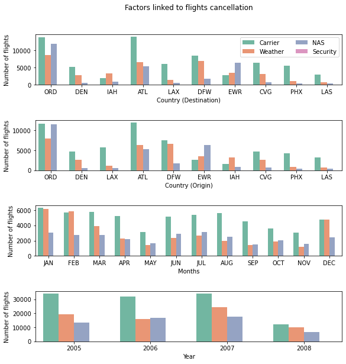

```python
plt.figure(figsize = [9, 9])
plt.suptitle('Factors linked to flights cancellation')
plt.subplots_adjust(left=0.1,
                    bottom=0.1,
                    right=0.9,
                    top=0.9,
                    wspace=0.4,
                    hspace=0.7)
# subplot 1: Destination vs CancellationCode
plt.subplot(4, 1, 1)
sb.countplot(data = df_dest_sorted, x = 'Dest', hue = 'CancellationCode', palette = "Set2")
plt.legend(ncol = 2) # re-arrange legend to reduce overlapping
plt.ylabel('Number of flights')
plt.xlabel('Country (Destination)')

# subplot 2: Origin vs. CancellationCode
plt.subplot(4, 1, 2)
sb.countplot(data = df_org_sorted, x = 'Origin', hue = 'CancellationCode', palette = "Set2")
leg =plt.legend()
leg.remove()
plt.ylabel('Number of flights')
plt.xlabel('Country (Origin)')

# subplot 3: Month vs. CancellationCode
ax = plt.subplot(4, 1, 3)
sb.countplot(data = df_org_sorted, x = 'Month', hue = 'CancellationCode', palette = "Set2")
leg =ax.legend()
leg.remove()
ax.set_ylabel('Number of flights')
ax.set_xlabel('Months')

# subplot 4: Year vs. CancellationCode
ax = plt.subplot(4, 1, 4)
sb.countplot(data = df_flights, x = 'Year', hue = 'CancellationCode', palette = "Set2")
leg =ax.legend()
leg.remove()
ax.set_ylabel('Number of flights')
ax.set_xlabel('Year')

plt.show()
```

## Arrival and departure delays by month on 10 most popular cities/countries

The majority of delayed flights at arrival are on **June** and **July** at **EWR** and **ATL**. On another hand, the majority of flights delayed at the depature are on **december**, **june** and **july** at **ORD** and **EWR**, followed by **ATL**.

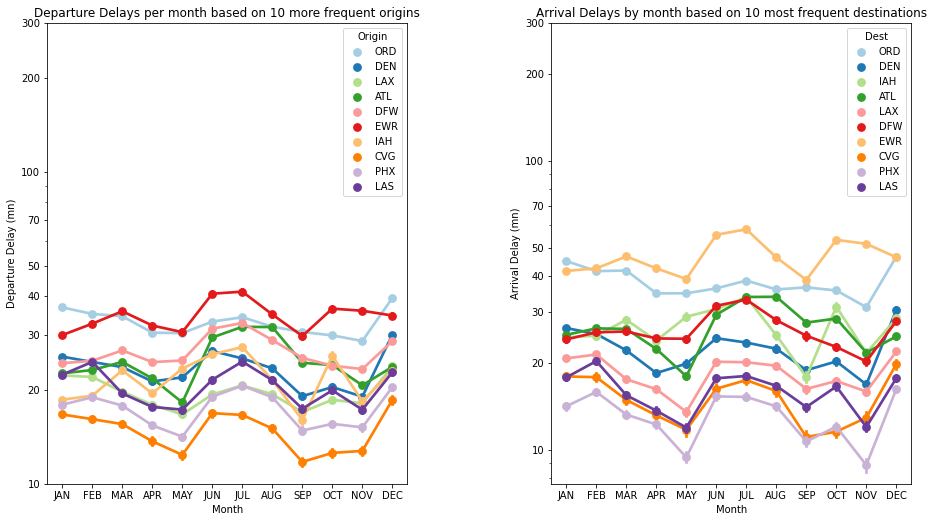

```python
fig, ax = plt.subplots(ncols =2, figsize=[15,8])
plt.subplots_adjust(left=0.1,
                    bottom=0.1,
                    right=0.9,
                    top=0.9,
                    wspace=0.4,
                    hspace=0.7)
titles = ['Departure Delays per month based on 10 more frequent origins','Arrival Delays by month based on 10 most frequent destinations']
cities = ['Origin','Dest']
for i in range(len(delay_params)):
    sb.pointplot(data = df_list[i], x = 'Month', y = delay_params[i], hue = cities[i],
           palette = 'Paired', dodge = 0,ax = ax[i])
    ax[i].set_title(titles[i])
    ax[i].set_ylabel(xlabels[i])
    ax[i].set_yscale('log')
    ax[i].set_yticks([10, 20, 30, 40, 50,70,100,200,300])
    ax[i].set_yticklabels([10, 20, 30, 40, 50,70,100,200,300])
    ax[i].set_yticklabels([],minor = True)
plt.show()
```

### Generate Slideshow

Once you're ready to generate your slideshow, use the `jupyter nbconvert` command to generate the HTML slide show.

```python
# Use this command if you are running this file in local
!jupyter nbconvert Part_II_slide_deck_Flights_Dataset.ipynb --to slides --post serve --no-input --no-prompt
!serve --template output_toogle.tpl
```

[output not shown]

> In the classroom workspace, the generated HTML slideshow will be placed in the home folder.

> In local machines, the command above should open a tab in your web browser where you can scroll through your presentation. Sub-slides can be accessed by pressing 'down' when viewing its parent slide. Make sure you remove all of the quote-formatted guide notes like this one before you finish your presentation! At last, you can stop the Kernel.

### Submission

If you are using classroom workspace, you can choose from the following two ways of submission:

1. **Submit from the workspace**. Make sure you have removed the example project from the /home/workspace directory. You must submit the following files:
   - Part_I_notebook.ipynb
   - Part_I_notebook.html or pdf
   - Part_II_notebook.ipynb
   - Part_I_slides.html
   - README.md
   - dataset (optional)
1. **Submit a zip file on the last page of this project lesson**. In this case, open the Jupyter terminal and run the command below to generate a ZIP file.

   ```
   zip -r my_project.zip .
   ```

   The command abobve will ZIP every file present in your /home/workspace directory. Next, you can download the zip to your local, and follow the instructions on the last page of this project lesson.